# Prediction Assignment Writeup

Leigh Pearson

2023-11-25

## Executive Summary

For this project, I developed a predictive model to determine the manner in which exercises were performed using data from accelerometers on the belt, forearm, arm, and dumbbell of 6 participants. My approach involved comprehensive data cleaning and preprocessing to handle missing values and ensure data integrity. I employed a Random Forest algorithm, leveraging its robustness in handling large datasets with multiple predictors. The model demonstrated high accuracy and was fine-tuned using cross-validation techniques, ensuring reliability in its predictive capabilities. The final model was tested against a separate dataset of 20 cases, predicting the exercise technique being used. The entire analysis, along with the model and its predictions, have been thoroughly documented and are available in a GitHub repository, showcasing both the methodology and the results in a comprehensible and accessible manner.

## Downloading and Cleaning the Data

options(repos = c(CRAN = “https://cran.rstudio.com/”))

install.packages(“dplyr”)

install.packages(“tidyr”)

install.packages(“ggplot2”)

```r
library(dplyr)
library(tidyr)
library(ggplot2)

training_url <- "https://d396qusza40orc.cloudfront.net/predmachlearn/pml-training.csv"
testing_url <- "https://d396qusza40orc.cloudfront.net/predmachlearn/pml-testing.csv"
training_data <- read.csv(training_url)
testing_data <- read.csv(testing_url)
```

Initial exploration reveals many columns with 19216 out of 19622 values missing, which is a very high percentage, and typically, such columns are not useful for predictive modeling or statistical analysis because they contain very little information. Therefore, I will remove these columns from both the training and testing datasets.

```r
threshold <- 0.5  # 50% missing values
training_data <- training_data[, colMeans(is.na(training_data)) < threshold]
```

There are also many variables with a very high percentage of empty strings, such as kurtosis_roll_belt, kurtosis_picth_belt, kurtosis_yaw_belt, and skewness_roll_belt. These were also identified and removed.

```r
# Calculate the proportion of empty strings in each column
empty_string_proportions <- sapply(training_data, function(x) {
  if(is.character(x)) {
    return(sum(x == "") / length(x))
  } else {
    return(0)
  }
})

# Set a threshold for high proportion
threshold <- 0.5  # 50% empty strings

# Identify columns exceeding the threshold
columns_to_remove <- names(which(empty_string_proportions > threshold))

# Remove these columns from the dataset
training_data <- training_data[, !names(training_data) %in% columns_to_remove]
```

In addition, many of the variables are not relevant to the analysis, such as the X, user_name, all timestamps, and window variables, so these were also removed.

```r
training_data <- training_data %>%
  select(
    -X,
    -user_name,
    -raw_timestamp_part_1,
    -raw_timestamp_part_2,
    -cvtd_timestamp,
    -new_window,
    -num_window
  )
```

Now that irrelevant and unhelpful variables have been removed, the same will be removed from the testing data. However, the Classe variable from the testing_data is missing as this is the variable that we must predict, so this will also be accounted for.

```r
training_vars <- setdiff(names(training_data), "classe")
testing_data_clean <- testing_data[, training_vars, drop = FALSE]
```

It also appears that the the Classe variable factors are labeled as A, B, C, D, and E, but these need renaming in both the training and testing datasets to make analysis more interpretable.

```r
training_data$classe <- factor(training_data$classe,
                               levels = c("A", "B", "C", "D", "E"),
                               labels = c("Correct", "ElbowThrow", "HalfLift", "HalfLower", "HipThrow"))
```

## Exploratory Data Analysis

A summary of the cleaned data is availbale in the Appendix. Next, we need an understanding of the distribution of the target variable classe.

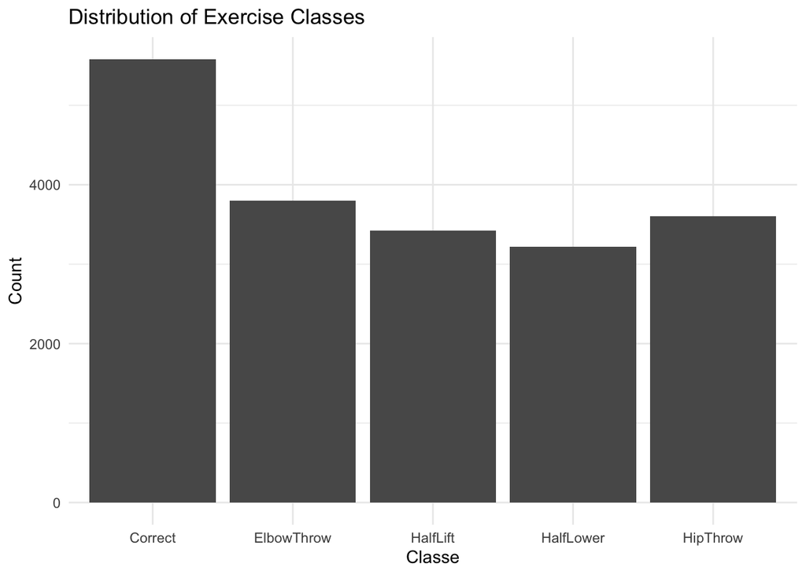

```r
library(ggplot2)
ggplot(training_data, aes(x = classe)) +
  geom_bar() +
  theme_minimal() +
  labs(title = "Distribution of Exercise Classes", x = "Classe", y = "Count")
```

Initial exploratory data analysis such as the histograpm below did not reveal any obvious outliers or differences.

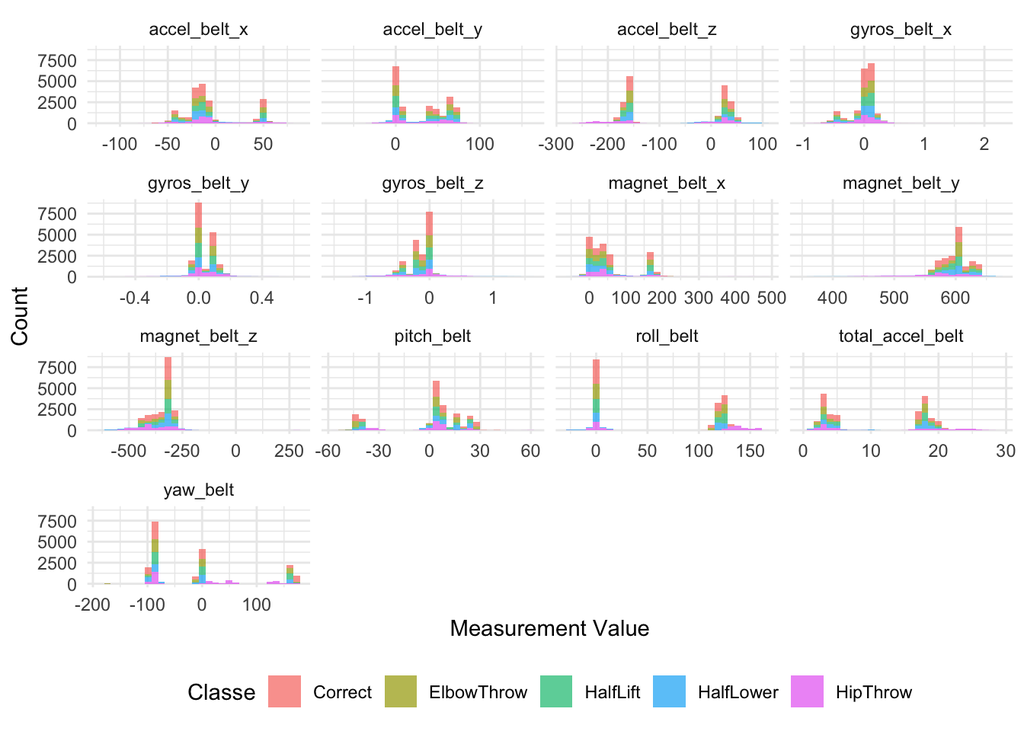

```r
library(tidyverse)

# Reshape the data to long format, keeping 'classe' separate
belt_data_long <- training_data %>%
  pivot_longer(
    cols = -classe, # Exclude 'classe' from the pivoting process
    names_to = "measurement",
    values_to = "value"
  ) %>%
  filter(str_detect(measurement, "belt")) # Keep only belt-related measurements

# Plot
belt_plots <- ggplot(belt_data_long, aes(x = value, fill = classe)) +
  geom_histogram(bins = 30, alpha = 0.7) +
  facet_wrap(~ measurement, scales = "free_x") +
  theme_minimal() +
  labs(x = "Measurement Value", y = "Count", fill = "Classe") +
  theme(legend.position = "bottom")

# Print the plots
print(belt_plots)
```

```r
library(randomForest)
library(caret)

set.seed(123) # for reproducibility
rf_model <- randomForest(classe ~ ., data=training_data, ntree=500)

set.seed(123)
train_control <- trainControl(method="cv", number=10) # 10-fold CV
rf_cv_model <- train(classe ~ ., data=training_data, method="rf", trControl=train_control, ntree=500)

rf_cv_model$results
```

```
##   mtry  Accuracy     Kappa  AccuracySD     KappaSD
## 1    2 0.9951073 0.9938107 0.001970498 0.002493520
## 2   27 0.9951076 0.9938114 0.001464885 0.001852671
## 3   52 0.9897566 0.9870416 0.002731869 0.003455937
```

## Cross Validation and Out-of-Sample Error

The results of the rf_cv_model cross-validation test reveals 27 random samples to be the optimal number, with the highest accuracy and Kappa scores. The final model can therefore be adjusted to include mtry 27 as follows:

```r
rf_model_optimized <- randomForest(
    classe ~ .,
    data = training_data,
    ntree = 500,
    mtry = 27
)
print(rf_model_optimized)
```

```
##
## Call:
##  randomForest(formula = classe ~ ., data = training_data, ntree = 500,      mtry = 27)
##                Type of random forest: classification
##                      Number of trees: 500
## No. of variables tried at each split: 27
##
##         OOB estimate of  error rate: 0.48%
## Confusion matrix:
##            Correct ElbowThrow HalfLift HalfLower HipThrow class.error
## Correct       5574          4        1         0        1 0.001075269
## ElbowThrow      22       3772        3         0        0 0.006584145
## HalfLift         0         11     3401        10        0 0.006136762
## HalfLower        1          1       26      3185        3 0.009639303
## HipThrow         0          1        5         5     3596 0.003049626
```

The optimized model also shows an out-of-bag (OOB) error rate of just 0.48%. This extremely low estimation of out-of-sample error rate, indicating that the model should be robust and reliable when applied to mew data.

## Model Testing

Before we attempt to make predictions on the testing data using the optimized model, we need to make the training and testing dataset variables consistent for the model to work.

```r
# Get the names of the variables in the training data, excluding 'classe'
training_vars <- setdiff(names(training_data), "classe")

# Subset the testing data to include only those variables present in the training data
testing_data_clean <- testing_data[, training_vars, drop = FALSE]
```

Now we can use the optimized model on each of the 20 test cases.

```r
predicted_classes <- predict(rf_model_optimized, newdata = testing_data_clean)
print(predicted_classes)
```

```
##          1          2          3          4          5          6          7
## ElbowThrow    Correct ElbowThrow    Correct    Correct   HipThrow  HalfLower
##          8          9         10         11         12         13         14
## ElbowThrow    Correct    Correct ElbowThrow   HalfLift ElbowThrow    Correct
##         15         16         17         18         19         20
##   HipThrow   HipThrow    Correct ElbowThrow ElbowThrow ElbowThrow
## Levels: Correct ElbowThrow HalfLift HalfLower HipThrow
```

These results more easily interpreted in a bar chart.

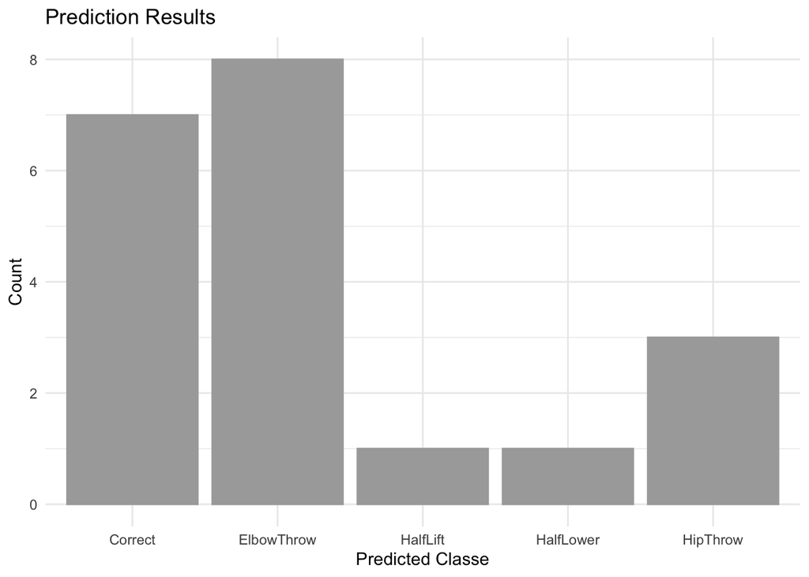

```r
predictions_df <- data.frame(Classe = predicted_classes)
ggplot(predictions_df, aes(x = Classe)) + geom_bar(color = "darkgrey", fill = "darkgrey") + theme_minimal() + labs(title = "Prediction Results", x = "Predicted Classe", y = "Count")
```

## Appendix

```r
head(training_data)
```

```
##   roll_belt pitch_belt yaw_belt total_accel_belt gyros_belt_x gyros_belt_y
## 1      1.41       8.07    -94.4                3         0.00         0.00
## 2      1.41       8.07    -94.4                3         0.02         0.00
## 3      1.42       8.07    -94.4                3         0.00         0.00
## 4      1.48       8.05    -94.4                3         0.02         0.00
## 5      1.48       8.07    -94.4                3         0.02         0.02
## 6      1.45       8.06    -94.4                3         0.02         0.00
##   gyros_belt_z accel_belt_x accel_belt_y accel_belt_z magnet_belt_x
## 1        -0.02          -21            4           22            -3
## 2        -0.02          -22            4           22            -7
## 3        -0.02          -20            5           23            -2
## 4        -0.03          -22            3           21            -6
## 5        -0.02          -21            2           24            -6
## 6        -0.02          -21            4           21             0
##   magnet_belt_y magnet_belt_z roll_arm pitch_arm yaw_arm total_accel_arm
```

[output cut: 62 more lines]

```r
summary(training_data)
```

```
##    roll_belt        pitch_belt          yaw_belt       total_accel_belt
##  Min.   :-28.90   Min.   :-55.8000   Min.   :-180.00   Min.   : 0.00
##  1st Qu.:  1.10   1st Qu.:  1.7600   1st Qu.: -88.30   1st Qu.: 3.00
##  Median :113.00   Median :  5.2800   Median : -13.00   Median :17.00
##  Mean   : 64.41   Mean   :  0.3053   Mean   : -11.21   Mean   :11.31
##  3rd Qu.:123.00   3rd Qu.: 14.9000   3rd Qu.:  12.90   3rd Qu.:18.00
##  Max.   :162.00   Max.   : 60.3000   Max.   : 179.00   Max.   :29.00
##   gyros_belt_x        gyros_belt_y       gyros_belt_z      accel_belt_x
##  Min.   :-1.040000   Min.   :-0.64000   Min.   :-1.4600   Min.   :-120.000
##  1st Qu.:-0.030000   1st Qu.: 0.00000   1st Qu.:-0.2000   1st Qu.: -21.000
##  Median : 0.030000   Median : 0.02000   Median :-0.1000   Median : -15.000
##  Mean   :-0.005592   Mean   : 0.03959   Mean   :-0.1305   Mean   :  -5.595
##  3rd Qu.: 0.110000   3rd Qu.: 0.11000   3rd Qu.:-0.0200   3rd Qu.:  -5.000
##  Max.   : 2.220000   Max.   : 0.64000   Max.   : 1.6200   Max.   :  85.000
##   accel_belt_y     accel_belt_z     magnet_belt_x   magnet_belt_y
##  Min.   :-69.00   Min.   :-275.00   Min.   :-52.0   Min.   :354.0
##  1st Qu.:  3.00   1st Qu.:-162.00   1st Qu.:  9.0   1st Qu.:581.0
##  Median : 35.00   Median :-152.00   Median : 35.0   Median :601.0
##  Mean   : 30.15   Mean   : -72.59   Mean   : 55.6   Mean   :593.7
##  3rd Qu.: 61.00   3rd Qu.:  27.00   3rd Qu.: 59.0   3rd Qu.:610.0
##  Max.   :164.00   Max.   : 105.00   Max.   :485.0   Max.   :673.0
##  magnet_belt_z       roll_arm         pitch_arm          yaw_arm
##  Min.   :-623.0   Min.   :-180.00   Min.   :-88.800   Min.   :-180.0000
##  1st Qu.:-375.0   1st Qu.: -31.77   1st Qu.:-25.900   1st Qu.: -43.1000
##  Median :-320.0   Median :   0.00   Median :  0.000   Median :   0.0000
##  Mean   :-345.5   Mean   :  17.83   Mean   : -4.612   Mean   :  -0.6188
##  3rd Qu.:-306.0   3rd Qu.:  77.30   3rd Qu.: 11.200   3rd Qu.:  45.8750
##  Max.   : 293.0   Max.   : 180.00   Max.   : 88.500   Max.   : 180.0000
##  total_accel_arm  gyros_arm_x        gyros_arm_y       gyros_arm_z
##  Min.   : 1.00   Min.   :-6.37000   Min.   :-3.4400   Min.   :-2.3300
##  1st Qu.:17.00   1st Qu.:-1.33000   1st Qu.:-0.8000   1st Qu.:-0.0700
##  Median :27.00   Median : 0.08000   Median :-0.2400   Median : 0.2300
##  Mean   :25.51   Mean   : 0.04277   Mean   :-0.2571   Mean   : 0.2695
##  3rd Qu.:33.00   3rd Qu.: 1.57000   3rd Qu.: 0.1400   3rd Qu.: 0.7200
##  Max.   :66.00   Max.   : 4.87000   Max.   : 2.8400   Max.   : 3.0200
##   accel_arm_x       accel_arm_y      accel_arm_z       magnet_arm_x
##  Min.   :-404.00   Min.   :-318.0   Min.   :-636.00   Min.   :-584.0
##  1st Qu.:-242.00   1st Qu.: -54.0   1st Qu.:-143.00   1st Qu.:-300.0
##  Median : -44.00   Median :  14.0   Median : -47.00   Median : 289.0
##  Mean   : -60.24   Mean   :  32.6   Mean   : -71.25   Mean   : 191.7
```

[output cut: 43 more lines]

```
##  Max.   :311.00000   Max.   :231.0000   Max.   : 477.00   Max.   : 923.0
##  accel_forearm_z   magnet_forearm_x  magnet_forearm_y magnet_forearm_z
##  Min.   :-446.00   Min.   :-1280.0   Min.   :-896.0   Min.   :-973.0
##  1st Qu.:-182.00   1st Qu.: -616.0   1st Qu.:   2.0   1st Qu.: 191.0
##  Median : -39.00   Median : -378.0   Median : 591.0   Median : 511.0
##  Mean   : -55.29   Mean   : -312.6   Mean   : 380.1   Mean   : 393.6
##  3rd Qu.:  26.00   3rd Qu.:  -73.0   3rd Qu.: 737.0   3rd Qu.: 653.0
##  Max.   : 291.00   Max.   :  672.0   Max.   :1480.0   Max.   :1090.0
##         classe
##  Correct   :5580
##  ElbowThrow:3797
##  HalfLift  :3422
##  HalfLower :3216
##  HipThrow  :3607
##
```

```r
str(training_data)
```

```
## 'data.frame':    19622 obs. of  53 variables:
##  $ roll_belt           : num  1.41 1.41 1.42 1.48 1.48 1.45 1.42 1.42 1.43 1.45 ...
##  $ pitch_belt          : num  8.07 8.07 8.07 8.05 8.07 8.06 8.09 8.13 8.16 8.17 ...
##  $ yaw_belt            : num  -94.4 -94.4 -94.4 -94.4 -94.4 -94.4 -94.4 -94.4 -94.4 -94.4 ...
##  $ total_accel_belt    : int  3 3 3 3 3 3 3 3 3 3 ...
##  $ gyros_belt_x        : num  0 0.02 0 0.02 0.02 0.02 0.02 0.02 0.02 0.03 ...
##  $ gyros_belt_y        : num  0 0 0 0 0.02 0 0 0 0 0 ...
##  $ gyros_belt_z        : num  -0.02 -0.02 -0.02 -0.03 -0.02 -0.02 -0.02 -0.02 -0.02 0 ...
##  $ accel_belt_x        : int  -21 -22 -20 -22 -21 -21 -22 -22 -20 -21 ...
##  $ accel_belt_y        : int  4 4 5 3 2 4 3 4 2 4 ...
##  $ accel_belt_z        : int  22 22 23 21 24 21 21 21 24 22 ...
##  $ magnet_belt_x       : int  -3 -7 -2 -6 -6 0 -4 -2 1 -3 ...
##  $ magnet_belt_y       : int  599 608 600 604 600 603 599 603 602 609 ...
##  $ magnet_belt_z       : int  -313 -311 -305 -310 -302 -312 -311 -313 -312 -308 ...
##  $ roll_arm            : num  -128 -128 -128 -128 -128 -128 -128 -128 -128 -128 ...
```

[output cut: 39 more lines]

```r
dim(training_data)
```

```
## [1] 19622    53
```

```r
table(training_data$classe)
```

```
##
##    Correct ElbowThrow   HalfLift  HalfLower   HipThrow
##       5580       3797       3422       3216       3607
```

```r
str(testing_data)
```

```
## 'data.frame':    20 obs. of  160 variables:
##  $ X                       : int  1 2 3 4 5 6 7 8 9 10 ...
##  $ user_name               : chr  "pedro" "jeremy" "jeremy" "adelmo" ...
##  $ raw_timestamp_part_1    : int  1323095002 1322673067 1322673075 1322832789 1322489635 1322673149 1322673128 1322673076 1323084240 1322837822 ...
##  $ raw_timestamp_part_2    : int  868349 778725 342967 560311 814776 510661 766645 54671 916313 384285 ...
##  $ cvtd_timestamp          : chr  "05/12/2011 14:23" "30/11/2011 17:11" "30/11/2011 17:11" "02/12/2011 13:33" ...
##  $ new_window              : chr  "no" "no" "no" "no" ...
##  $ num_window              : int  74 431 439 194 235 504 485 440 323 664 ...
##  $ roll_belt               : num  123 1.02 0.87 125 1.35 -5.92 1.2 0.43 0.93 114 ...
##  $ pitch_belt              : num  27 4.87 1.82 -41.6 3.33 1.59 4.44 4.15 6.72 22.4 ...
##  $ yaw_belt                : num  -4.75 -88.9 -88.5 162 -88.6 -87.7 -87.3 -88.5 -93.7 -13.1 ...
##  $ total_accel_belt        : int  20 4 5 17 3 4 4 4 4 18 ...
##  $ kurtosis_roll_belt      : logi  NA NA NA NA NA NA ...
##  $ kurtosis_picth_belt     : logi  NA NA NA NA NA NA ...
##  $ kurtosis_yaw_belt       : logi  NA NA NA NA NA NA ...
```

[output cut: 86 more lines]

```r
dim(testing_data)
```

```
## [1]  20 160
```